# What the future tells you about the present

A walkthrough of the aciR package, from one function call to the point where it refuses to answer

Published

2026-08-17

Abstract

Assimilative causal inference measures how much the later part of an observed signal sharpens an estimate of something that was never observed. This walkthrough climbs five rungs, from a single function call on a two-variable system to a six-dimensional climate model, and ends at the boundary where the package reports that the record ran out before the question could be settled. Every number and figure below is produced by running the code shown, on systems that are published and cited.

The depth of the thermocline under the Pacific drives the sea-surface temperatures that satellites record, and is itself far harder to observe. That shape recurs everywhere: you have a signal you can measure, and you want the state of something you cannot. This package answers one narrow, answerable question about that pair. Given everything the observed signal goes on to do *after* a given moment, how much better can you say what the unobserved state was *at* that moment, and how far ahead do you have to look before the answer stops improving?

Those are two different questions, and they get two different numbers. What follows climbs from a single function call to the point where the second question can no longer be answered from the record in hand, and the package says so.

## 1 What this document is

Assimilative causal inference is a method for conditional Gaussian nonlinear systems, published by Andreou et al. (2026). A conditional Gaussian nonlinear system is one in which an observed signal evolves nonlinearly, while the unobserved component, *conditional on the observed path*, has Gaussian statistics available in closed form. That closed form is what makes the method exact rather than approximate.

Two quantities follow from it. The **causal-information metric** is the relative entropy, also called the Kullback-Leibler divergence, of the smoother posterior from the filter posterior at each instant. In words: how much the future of the observed record sharpens the estimate. The **causal influence range** is the second quantity, and it asks how far ahead one must look before that sharpening stops.

On the inputs The systems below are published mathematical models, and the paths are simulated realisations of them or fixtures generated from the reference implementation. **They are not observational records.** In particular, the El Niño Southern Oscillation section uses a simulated realisation of a published climate model, not measured sea-surface temperatures, and nothing here supports an empirical claim about the climate. The models, and the findings that use them, are in the source paper.

Requirements `aciR` (0.2.3 or later), `ggplot2` and `DT`. Nothing is downloaded: every fixture read below ships inside the installed package. To install:

```r
# install.packages("remotes")
remotes::install_github("biometryhub/ACI", subdir = "aciR")
```

## 2 Rung 1: the whole method in one call

Rung 1 of 5

The nonlinear dyad is the smallest system worth the trouble. One observed variable, one unobserved variable, and a coupling that produces intermittent bursts rather than steady behaviour. Those bursts are the interesting part, because that is where the future of the observed signal has the most to say.

`aci()` runs the whole workflow: the forward filter, the backward smoother, and the metric that contrasts them.

```r
model <- aci_dyad_model()
sim <- aci_simulate(model, n = 6000, seed = 42)
result <- aci(sim$x, model, dt = 0.001)

result
```

```
#> <aci> assimilative causal inference
#>   model: nonlinear dyad model with intermittent extreme events
#>   steps: 6000, dt: 0.001, time span: [0, 5.999]
#>   causal-information metric:
#>    Min. 1st Qu.  Median    Mean 3rd Qu.    Max.
#> 0.00000 0.06639 0.11960 0.16478 0.20103 1.07480
```

The `print` method leads with the distribution of the metric rather than a single number, because a single number would hide the thing that matters: the metric is small most of the time and large in short episodes.

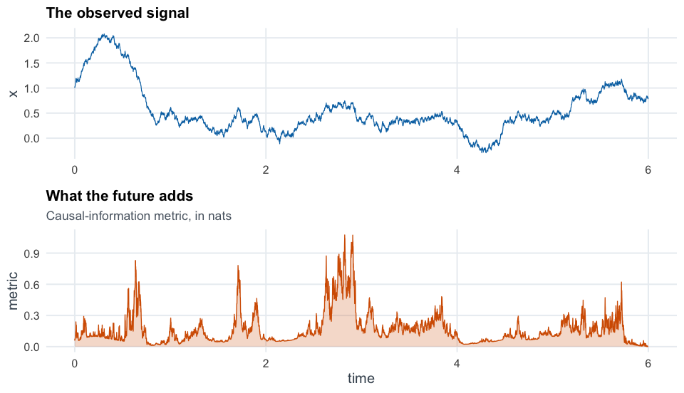

```r
d <- as.data.frame(result)

p1 <- ggplot(d, aes(t, x)) +
  geom_line(linewidth = .32, colour = pal[1]) +
  labs(title = "The observed signal", y = "x", x = NULL)

p2 <- ggplot(d, aes(t, aci)) +
  geom_area(fill = pal[2], alpha = .22) +
  geom_line(linewidth = .38, colour = pal[2]) +
  labs(
    title = "What the future adds",
    subtitle = "Causal-information metric, in nats",
    y = "metric", x = "time"
  )

patch <- function(a, b) {
  gridExtra::grid.arrange(a, b, ncol = 1, heights = c(1, 1.15))
}
if (requireNamespace("gridExtra", quietly = TRUE)) {
  patch(p1, p2)
} else {
  print(p2)
}
```

The metric peaks where the signal does something abrupt. That is the substantive reading: during a burst, the record that arrives afterwards carries a great deal of information about what the unobserved component was doing at the time, and during quiet stretches it carries much less.

## 3 Rung 2: how far ahead must you look?

Rung 2 of 5

The metric says *how much*. It does not say *how long*. Two systems can sharpen an estimate by the same total amount, one settling within a few steps and the other still improving thousands of steps later. The causal influence range separates them.

```r
comp <- aci_dyad_components(sim$x, model$parameters)
filt <- aci_filter(sim$x, comp, dt = 0.001, mu0 = model$y0, R0 = 0.1)

cir <- aci_cir(
  sim$x, comp,
  dt = 0.001, filt = filt,
  window = seq(500L, 3000L, by = 250L)
)

cir
```

```
#> Causal influence range
#>   11 reported times, 0.499 to 2.999; 129 thresholds
#>   status: resolved 9  censored 2  below_threshold 0  insufficient 0
#>   objective range: median 0.1741 (0.075 to 0.2473)
#>   2 times are censored; those ranges are lower bounds
```

```r
cd <- as.data.frame(cir)
tbl(cd[, c("time", "objective", "objective_exact", "peak",
           "status", "monotone")])
```

| time | objective | objective_exact | peak | status | monotone |
| --- | --- | --- | --- | --- | --- |
| 0.499 | 0.075 | 0.1547 | 0.3247 | resolved | False |
| 0.749 | 0.1646 | 0.5736 | 0.08798 | resolved | False |
| 0.999 | 0.1354 | 0.3745 | 0.27 | resolved | False |
| 1.249 | 0.1979 | 0.621 | 0.2552 | resolved | False |
| 1.499 | 0.1221 | 0.4034 | 0.4945 | resolved | False |
| 1.749 | 0.1835 | 0.4704 | 0.3262 | resolved | False |
| 1.999 | 0.2473 | 0.795 | 0.2033 | resolved | False |
| 2.249 | 0.2161 | 0.5776 | 0.3633 | resolved | False |
| 2.499 | 0.1864 | 0.3307 | 0.6455 | resolved | False |
| 2.749 | 0.1546 | 0.2066 | 0.8676 | censored | False |

[output cut: 1 more lines]

Why the two ranges differ `objective_exact` averages the per-threshold ranges over the whole threshold grid, which is the definition in the source paper. `objective` is the efficient approximation the paper also gives. They agree when the divergence sequence decreases with lag, by the layer-cake identity. The `monotone` column reports that condition, and here it is `FALSE` at every reported time, so the gap is definitional rather than a defect in either. The package reports both instead of picking one, because which is wanted depends on whether you need the definition or the cheaper computation.

## 4 Rung 3: the question is not symmetric

Rung 3 of 5

Nothing so far distinguishes “what x says about y” from “what y says about x”. A stochastic predator-prey system makes the asymmetry concrete, because the same pair of populations can be read in either causal direction. Observe the prey and infer the predator, or observe the predator and infer the prey.

```r
pp <- read.csv(ex("predprey_signal.csv"))
params <- aci_predprey_model()$parameters

run_direction <- function(direction) {
  observed <- if (direction == "predator_to_prey") pp$prey else pp$predator
  cmp <- aci_predprey_components(observed, params, direction)
  f <- aci_filter(observed, cmp, dt = 0.005, mu0 = 4, R0 = 0.1)
  s <- aci_smoother(observed, cmp, dt = 0.005, filt = f)
  data.frame(
    direction = direction,
    observed = if (direction == "predator_to_prey") "prey" else "predator",
    mean = mean(aci_metric(f, s)),
    peak = max(aci_metric(f, s)),
    drift_low = min(cmp$L_y),
    drift_high = max(cmp$L_y)
  )
}

both <- do.call(rbind, lapply(
  c("predator_to_prey", "prey_to_predator"), run_direction
))
tbl(both)
```

| direction | observed | mean | peak | drift_low | drift_high |
| --- | --- | --- | --- | --- | --- |
| predator_to_prey | prey | 0.3214 | 4.229 | -0.3705 | 0.8174 |
| prey_to_predator | predator | 0.7406 | 4.385 | -1.158 | 0.8386 |

The mean metric differs by roughly a factor of two between the two readings of one system. Watching the predator tells you more about the prey than the reverse, at these parameters.

This system also exercises something the dyad does not. The unobserved component’s own drift coefficient is set by the observed state, so it moves over the record and changes sign, shown by the `drift_low` and `drift_high` columns. The latent process is damped at some times and driven at others, which a system with a constant coefficient cannot express.

## 5 Rung 4: six dimensions, and what one channel contributes

Rung 4 of 5

The El Niño Southern Oscillation model in the source paper is the largest system the package expresses: six dimensions, three observed and three unobserved, with coefficients that vary seasonally and noise covariances that vary in time.

```r
enso <- read.csv(ex("enso_signal.csv"))
p <- aci_enso_parameters()
emodel <- aci_enso_model(p)

c(observed = paste(emodel$observed, collapse = ", "),
  unobserved = paste(emodel$unobserved, collapse = ", "))
```

```
#>      observed    unobserved
#> "T_C, T_E, I" "u, h_W, tau"
```

The observed channels are the central- and eastern-Pacific temperature anomalies and the Walker circulation strength. The unobserved ones are the zonal current, the thermocline depth and the wind burst.

```r
ecomp <- aci_enso_components(
  enso$T_C, enso$T_E, enso$I, p = p, time = enso$t, dt = 0.005
)
xm <- rbind(enso$T_C, enso$T_E, enso$I)
mu0 <- c(6.9136e-04, -0.0028, -0.0256)
R0 <- 0.01 * diag(3L)

ef <- aci_filter(xm, ecomp, dt = 0.005, mu0 = mu0, R0 = R0)
es <- aci_smoother(xm, ecomp, dt = 0.005, filt = ef)
joint <- aci_metric(ef, es)

c(mean = mean(joint), peak = max(joint), at_time = enso$t[which.max(joint)])
```

```
#>       mean       peak    at_time
#>  0.7817551  2.3470037 12.1400000
```

Six dimensions defeat the eye At three observed and three unobserved dimensions there is no plot that settles whether this is right. A time series of the metric can be shown, and is below, but it is orientation rather than proof. What establishes the numbers is the parity grading described at the end of this document, in which each quantity is compared against the authors’ own code on the same input. Treat the figure as a picture of the answer, not as evidence for it.

`aci_conditional()` asks a sharper question: what does one observed channel contribute, when the others are still present in the system but the filter stops assimilating them?

```r
channels <- c("T_C", "T_E", "I")

contribution <- do.call(rbind, lapply(seq_along(channels), function(i) {
  cc <- aci_conditional(ecomp, target = i)
  f <- aci_filter(xm, cc, dt = 0.005, mu0 = mu0, R0 = R0)
  s <- aci_smoother(xm, cc, dt = 0.005, filt = f)
  m <- aci_metric(f, s)
  data.frame(channel = channels[i], mean = mean(m), peak = max(m))
}))
contribution <- rbind(
  contribution,
  data.frame(channel = "all three", mean = mean(joint), peak = max(joint))
)
tbl(contribution)
```

| channel | mean | peak |
| --- | --- | --- |
| T_C | 0.8702 | 3.444 |
| T_E | 0.5126 | 2.034 |
| I | 6.682e-05 | 0.1225 |
| all three | 0.7818 | 2.347 |

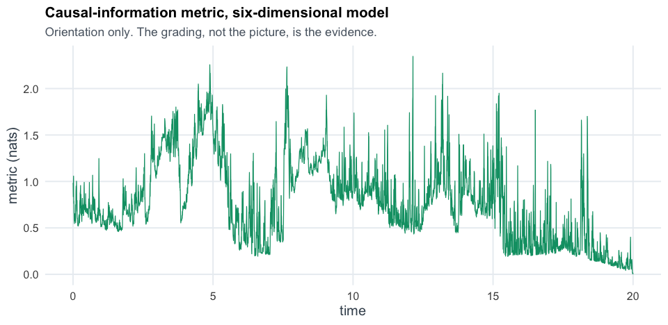

```r
ggplot(
  data.frame(t = enso$t, metric = joint),
  aes(t, metric)
) +
  geom_line(linewidth = .34, colour = pal[3]) +
  labs(
    title = "Causal-information metric, six-dimensional model",
    subtitle = "Orientation only. The grading, not the picture, is the evidence.",
    x = "time", y = "metric (nats)"
  )
```

The central-Pacific channel on its own scores *higher* than all three channels together, and the three parts sum to well over the whole. That is the easiest result in this document to misread, so it is worth taking apart rather than asserting an explanation for.

The tempting explanation is that a filter given fewer channels is worse, which leaves the future more room to improve on it. That explanation is wrong, and the package’s own output refutes it: restricted to the central-Pacific channel, the *smoother’s* posterior widens by more than the filter’s does, not less. Something else is moving.

Between two Gaussians the divergence splits into exactly two pieces. One is the change in spread, how much narrower the smoother posterior is. The other is the distance between the two posterior means, measured in filter precisions. Computing both from the same filter and smoother the package returns shows which one carries the metric.

```r
kl_parts <- function(cmp) {
  f <- aci_filter(xm, cmp, dt = 0.005, mu0 = mu0, R0 = R0)
  s <- aci_smoother(xm, cmp, dt = 0.005, filt = f)
  n <- dim(f$cov)[3L]
  spread <- mean_shift <- numeric(n)
  for (i in seq_len(n)) {
    prec <- solve(f$cov[, , i])
    gap <- f$mean[, i] - s$mean[, i]
    spread[i] <- 0.5 * (sum(diag(prec %*% s$cov[, , i])) - 3 +
                          log(det(f$cov[, , i]) / det(s$cov[, , i])))
    mean_shift[i] <- 0.5 * as.numeric(t(gap) %*% prec %*% gap)
  }
  data.frame(spread = mean(spread), mean_shift = mean(mean_shift),
             total = mean(spread + mean_shift))
}

split <- do.call(rbind, lapply(
  list(ecomp, aci_conditional(ecomp, 1L), aci_conditional(ecomp, 2L),
       aci_conditional(ecomp, 3L)),
  kl_parts
))
split <- cbind(assimilating = c("all three", "T_C", "T_E", "I"), split)
split$mean_shift_pct <- round(100 * split$mean_shift / split$total)
tbl(split)
```

| assimilating | spread | mean_shift | total | mean_shift_pct |
| --- | --- | --- | --- | --- |
| all three | 0.189 | 0.5928 | 0.7818 | 76 |
| T_C | 0.1825 | 0.6877 | 0.8702 | 79 |
| T_E | 0.1476 | 0.365 | 0.5126 | 71 |
| I | 6.666e-05 | 1.604e-07 | 6.682e-05 | 0 |

The `total` column reproduces the metric reported above, which is the check that this decomposition is of the same quantity and not a different one.

What the table shows Roughly three quarters of the metric is the distance between the two posterior means, not the narrowing of the posterior. Restricting to the central-Pacific channel leaves the spread term essentially unchanged and raises the mean term. The metric therefore reports mostly how far the future *moves* the estimate, and only secondarily how much it *sharpens* it.

Two consequences follow, and they are the practical ones. The quantity is not a decomposition, so per-channel values cannot be added and cannot be read as a ranking of channel importance. And a channel scoring near zero, as the Walker circulation does here on both terms, is saying that its future neither moves nor sharpens the estimate beyond its own past. That is not the same as the channel being uninformative about the system.

The estimand is worth stating exactly, because four different quantities get confused here. The metric is the relative entropy of $p(y_t \mid x_{0:T})$ from $p(y_t \mid x_{0:t})$. It is not an interventional quantity, not a Granger test and not transfer entropy, although all four can be large at the same instants. Conditioning changes what the filter assimilates, not the system that produced the path.

## 6 Rung 5: where the package refuses

Rung 5 of 5

The binding constraint here is neither dimension nor runtime. It is how much record remains *after* the moment you asked about. To find how far ahead the influence reaches, the record has to reach at least that far, and near the end of a record it does not.

This is a property of the question rather than of the software. No method, in any language, can measure an influence extending further than the data it was given, and an implementation that returned a confident number there would be inventing it. What distinguishes implementations is whether they report the shortfall or absorb it silently into a plausible-looking value.

So the last rung is not a limitation being disclosed. It is the behaviour worth checking for before trusting any of the previous four. The same system is interrogated at thirty times, marching toward the end of the record.

```r
sim2 <- aci_simulate(model, n = 4000, seed = 7)
comp2 <- aci_dyad_components(sim2$x, model$parameters)
filt2 <- aci_filter(sim2$x, comp2, dt = 0.001, mu0 = model$y0, R0 = 0.1)

edge <- aci_cir(
  sim2$x, comp2,
  dt = 0.001, filt = filt2,
  window = seq(1000L, 3900L, by = 100L)
)

ed <- as.data.frame(edge)
ed$lookahead <- nrow(sim2) - ed$index
table(ed$status)
```

[output not shown]

[figure not shown]

```r
ggplot(ed, aes(lookahead, objective, colour = status)) +
  geom_point(size = 2.1) +
  geom_line(aes(group = 1), linewidth = .3, colour = "#9aa5b1") +
  scale_x_reverse() +
  scale_colour_manual(values = c(resolved = pal[3], censored = pal[2])) +
  labs(
    title = "The boundary is the record that remains, not the model",
    subtitle = paste(
      "Reading right to left, each point sits closer to the end of the record."
    ),
    x = "steps of record remaining after the reported time",
    y = "objective range"
  )
```

The status changes from `resolved` to `censored` partway along. The rule is explicit: a time is censored when the divergence has not settled below `threshold` until it has consumed more than `1 - margin` of the record available after it. At the default `margin = 0.1`, that means more than 90%.

What the package does *not* do at that point is return `NA`. A censored time still yields a statement the record supports, namely that the range is at least this long, so the value stands and the status records that it is a lower bound. Discarding it would throw away information exactly at the end of the record, which is where somebody studying a recent event is looking. Only a time with fewer than three later observations, where no quadrature is possible at all, returns `NA`.

What to take from this rung A range reported near the end of a record is a lower bound, and the `status` column is how you tell. Two habits follow. Check `status` before quoting a range. And when you design a record, leave more tail than the influence you expect to measure, because the tail is the binding constraint.

## 7 How these numbers are checked

A reimplementation tested only against fixtures its own author transcribed demonstrates self-consistency and nothing more. If the author misread an equation, the fixture encodes the same misreading and passes.

Every numerical claim in this package is therefore graded against a source that did not also produce the code under test. The authors publish their work as MATLAB scripts rather than as a callable library, so their computational passages are lifted into callable functions as byte-exact slices, never retyped, and a checker fails on a single byte of drift. Both implementations then run on the same input and are compared quantity by quantity.

```r
tbl(data.frame(
  check = c(
    "Extract outputs reproducing the reference's own workspace",
    "Verbatim reference lines, none retyped",
    "Scalar core against the reference",
    "Predator-prey, both directions, filter through influence range"
  ),
  result = c(
    "156 of 156, difference exactly 0",
    "2,159 lines across 33 extracts",
    "26 of 26 quantities, worst 1.5e-14",
    "26 graded quantities, worst 1.5e-12"
  )
))
```

| check | result |
| --- | --- |
| Extract outputs reproducing the reference's own workspace | 156 of 156, difference exactly 0 |
| Verbatim reference lines, none retyped | 2,159 lines across 33 extracts |
| Scalar core against the reference | 26 of 26 quantities, worst 1.5e-14 |
| Predator-prey, both directions, filter through influence range | 26 graded quantities, worst 1.5e-12 |

For scale, an experiment comparing independently developed implementations of the same algorithms on identical input found agreement degrading from six significant figures to one (Hatton, 1997).

The full record is in the parity ledger, and the design history, with what remains open, is in the development ledger.

## 8 Where to go next

```r
tbl(data.frame(
  rung = c("1", "2", "3", "4", "5"),
  question = c(
    "How much does the future add?",
    "How far ahead must I look?",
    "Does the direction matter?",
    "What does one channel contribute?",
    "When should I not trust the answer?"
  ),
  entry_point = c(
    "aci()", "aci_cir()", "aci_predprey_components()",
    "aci_conditional()", "the status column of aci_cir()"
  )
))
```

| rung | question | entry_point |
| --- | --- | --- |
| 1 | How much does the future add? | aci() |
| 2 | How far ahead must I look? | aci_cir() |
| 3 | Does the direction matter? | aci_predprey_components() |
| 4 | What does one channel contribute? | aci_conditional() |
| 5 | When should I not trust the answer? | the status column of aci_cir() |

Three articles ship with the package. *Assimilative causal inference on the nonlinear dyad model* is the worked tutorial. *Assumptions and interpretation* states the conditions under which the method applies and what a peak does and does not support, and it is the right next read after the two warnings above. *Validation and the independent oracle* records what each oracle grades and, for each, what it does not.

## 9 References

Andreou, M., Chen, N. and Bollt, E. (2026). Assimilative causal inference. *Nature Communications*, **17**, 1854. [doi:10.1038/s41467-026-68568-0](https://doi.org/10.1038/s41467-026-68568-0)

Andreou, M., Chen, N. and Li, Y. (2026). An adaptive online smoother with closed-form solutions and information-theoretic lag selection for conditional Gaussian nonlinear systems. *Journal of Nonlinear Science*, **36**(4), 71. [doi:10.1007/s00332-026-10271-x](https://doi.org/10.1007/s00332-026-10271-x)

Hatton, L. (1997). The T experiments: errors in scientific software. *IEEE Computational Science and Engineering*, **4**(2), 27-38. [doi:10.1109/99.609829](https://doi.org/10.1109/99.609829)

## 10 Citation and licence

Cite the package as `citation("aciR")`. The method is the authors’ and should be cited alongside any use of this software; the reference is the first entry above.

`aciR` is MIT licensed, Copyright © 2026 Max Moldovan. The reference implementation, [`marandmath/ACI_code`](https://github.com/marandmath/ACI_code), is separately MIT licensed, Copyright © 2025 Marios Andreou, and is not redistributed with this package. This document inherits the MIT licence of both.